# Preparing demographic data with the demprep package

John Bryant, Bayesian Demography Limited

25 July 2021

# 1 Introduction

Demographic analyses typically use tabular data with standardised age groups and periods, like this:

Counts of deaths by age group and year

|  | 2020 | 2021 | 2022 |
| --- | --- | --- | --- |
| 0-4 | 3 | 5 | 4 |
| 5-9 | 0 | 0 | 0 |
| 10-14 | 1 | 2 | 2 |

However, raw data from registration systems or surveys typically reports individual events, with dates rather than age groups or periods:

Deaths by date of birth and date of death

| name | date_of_birth | date_of_death |
| --- | --- | --- |
| Alice | 2022-04-17 | 2022-07-19 |
| Bilal | 2009-12-03 | 2021-10-18 |
| Clara | 2020-07-01 | 2022-14-16 |
| Djeneba | 2011-11-29 | 2022-08-07 |
| Ergi | 2020-05-16 | 2020-06-03 |
| Faisal | 2018-03-30 | 2020-01-13 |

Even data that has been processed may use formats we do not want, or may contain gaps,

Counts of deaths by age group and year

| age | year | count |
| --- | --- | --- |
| Infant | 2017 | 2 |
| 2 years | 2020 | 1 |
| 12 years | 2020 | 1 |
| Infants | 2021 | 3 |
| 1 year | 2021 | 2 |

Getting from raw or partly-processed data to data that is ready for demographic analysis can be deceptively difficult. Consider, for instance, the task of assigning people to one-month age groups. When does a person who was born on 31 January 2001 turn one month old? According to the base R function `seq.Date`, the answer is 3 March 2001:

```r
seq.Date(from = as.Date("2001-01-31"),
         by = "month",
         length.out = 2)
```

```
#> [1] "2001-01-31" "2001-03-03"
```

Package **demprep** provides functions for processing data to the point where it is ready for demographic analysis. **demprep** focuses in particular on ages and periods, since this is typically the hardest part of preparing demographic data. **demprep** is designed to work with the other **dem** packages (which are still being written) but can be used on its own.

# 2 Background

## 2.1 Calculating age

In demography, as in ordinary English, “age” normally means “age in completed years”. For instance, demographers describe a person who was born 5 years and 57 days ago as 5 years old. If, instead of years, demographers are using moths, then age means age in completed months. Demographers describe a person who was born 3 months and 23 days ago as 3 months old.

Calculating ages is, however, complicated by the fact that length of the units, as measured days elapsed, is not constant. Leap years are one day longer than non-leap years, for instance, and May has one more day than April.

The basic rule used by **demprep** is that a person gains a extra month of age each time the person attains the day-of-the-month that they were born. If a person was born on 5 March 2000, for instance, then the person turns one month old on 5 April 2000, turns 2 months old on May 2000, turns 12 months old on 5 March 2001, and so on.

The basic rule needs to be extended, however, to deal with cases when a month does not contain the day-of-the-month when a person was not born. The basic rule does not, for instance, allow us to say when a person who was born on 31 January turns one month old, since February does not contain a 31st day.

To deal with such cases, **demprep** follows the principle that if the day-of-the-month when a person was born does not occur during a month, then the person gains the the extra month of age on the first day of the next month. A person who is born on 31 January 2000 turns one month old on 1 March 2000.

Age in completed years can be obtained by dividing age in completed months by 12, and discarding any remainder. If a person is aged 123, measured in completed months, then the person is aged 10, measured in completed years.

The **demprep** approach to calculating age requires accepting some inconsistency, in that the same age measured in months can correspond to different ages measured in days, depending on the time of year. This inconsistency is, however, unavoidable, if ages and periods are to line up in the way that people typically expect them to. It is the approach we must take if, for instance, group of people who are aged $x$ months on 1 February are to be aged $x+1$ months on 1 March, and $x+2$ months on 1 April.

## 2.2 Definining age groups, periods, cohorts, and Lexis triangles

Age groups are intervals involving age, such as all ages from 10 years to 14 years. Periods are intervals involving time, such as all times from 1 January 2030 to 31 December 2030.

Although people sometimes use “age cohort” as a synonym for “age group”, a cohort and an age group are in fact different things. A cohort is a group of people who all experienced a particular event during some specified period. The particular event is almost always births, so that a cohort is everyone born during the 1960s, for instance, or everyone born in 2007. However, cohorts can also be defined by other events, such as everyone who married during a particular decade, or everyone who started at an organization during a particular year.

One way of visualising age groups, periods, and cohorts is through a Lexis diagram. The diagram below is an example. The horizontal axis represents time, and the vertical axis represent age. The horizontal grid lines mark out age groups. The age group “5-9” for instance, starts at exact age 5 and finishes just before exact age 10. The vertical grid lines mark out periods. The period “2005-2010”, for instance, starts on 1 January 2005 and ends just before 1 January 2010. The diagonal lines mark out cohorts. The cohort “2000-2005”, for instance, starts down the bottom left of the diagram, and ends at the top right, at which point the date is 1 January 2025 and people in the cohort are aged 20-24.

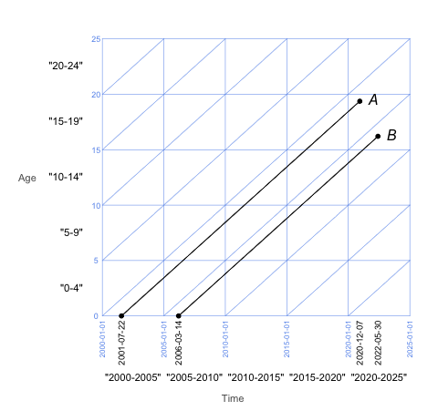

A Lexis diagram

The two black diagonal lines in the diagram above are “life lines”. They depict the lives of individuals A and B from the time of their births, in periods 2000-2005 and 2005-2010, to the time of the deaths, in 2020-2025.

Assigning deaths to cohorts

[output not shown]

Ambiguities over cohorts are common: we often know the age group and period that events belong to, but cannot work out which of two possible cohorts we should assign the events to. This ambiguity can be removed if, in addition to age group and period, we also know the “Lexis triangle” to which the events belong. Lexis triangle is a technical demographic term that is not well known, but that turns out to be extremely useful in any analysis that requires working with age groups and cohorts.

Consider again the Lexis diagram above. Lexis triangles in the diagram are formed by the intersection of the horizontal, vertical, and diagonal lines. The triangles below the diagonal lines are known as lower Lexis triangles, and the triangles above the diagonal lines are known as upper Lexis triangles.

The death of individual A in the Lexis diagram above belongs to the upper Lexis triangle, while the death of individual B belongs to the lower Lexis triangle. Events in the upper triangle belong to the earlier of the two possible cohorts, and events in the lower triangle belong to the later of the two. Supplementing information on age group and period with information on Lexis triangle allows us to unambiguously assign events to cohorts.

Assigning deaths to cohorts (with Lexis triangle)

[output not shown]

Lexis triangles provide the extra information needed to distinguish between cohorts when dealing with events that are categorised by age group and period. Consider, for instance, the black dots $A$ and $B$ in the diagram above. The dots represent deaths, and the black diagonal lines are “life lines” for the people experiencing these deaths. The two deaths belong to the same period (2020-2025) and the same age group (15-19). The deaths do not, however, belong to the same cohort: death $A$, however, belongs to cohort 2000-2005, while death $B$ belongs to cohort 2005-2010. Knowing the period and age group for deaths $A$ and $B$ is not enough, on its own, to assign each death to a cohort. If, however, we also know that death $A$ belongs to the upper Lexis triangle, and death $B$ belongs to the lower Lexis triangle, then we can assign the deaths to cohorts.

Cohorts and Lexis triangles require time steps and age steps to have equal sizes. In the Lexis diagram above, for instance, the time steps and age steps are both 5 years. Demographic data does not always use the same size steps for age and time. The Lexis diagram beow, for instance, has 10-year time steps and 5-year age steps. When time steps and age steps are different lengths, defining cohorts and Lexis triangles is difficult.

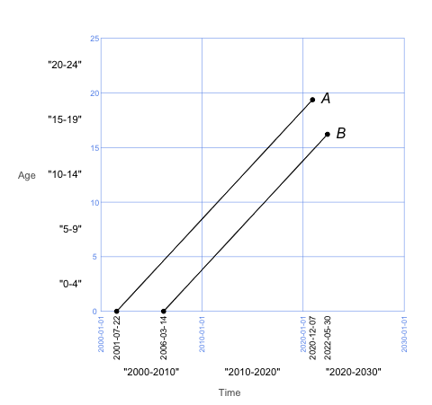

A Lexis diagram with time steps and age steps of different lengths

## 2.3 Labels for age groups, periods, and cohorts

Different produces of demographic data use many different schemes for labeling age groups, periods, and cohorts. **demprep** implements a system of labeling that tries to reflect common practices, while also being concise. The table below summarises the system. Dashes indicate combinations that are not allowed.

**demprep** labels for age groups, periods, and cohorts

| Unit | Type | Age group | Period | Cohort |
| --- | --- | --- | --- | --- |
| year | single | `"5"` | `"2020"` | `"2020"` |
| year | multiple | `"5-9"` | `"2025-2030"` | `"2025-2030"` |
| year | open left | - | - | `"<2020"` |
| year | open right | `"100+"` | - | - |
| quarter | single | `"20"` | `"2020 Q1"` | `"2020 Q1"` |
| quarter | multiple | - | - | - |
| quarter | open left | - | - | `"<2020 Q1"` |
| quarter | open right | `"400+"` | - | - |
| month | single | `"60"` | `"2020 Jan"` | `"2020 Jan"` |
| month | multiple | - | - | - |
| month | open left | - | - | `"<2020 Jan"` |
| month | open right | `"1200+"` | - | - |

**demprep** caters to three types of units: years, quarters, and months. Age intervals can be open on the right, such as the age group consisting of people aged 100 years or more. Cohorts can be open on the left, such as the cohort consisting of people born before January 2020. Multi-year intervals, such as ages 5 to 9 years, are allowed, but multi-quarter or multi-month intervals are not.

Reflecting standard practice, **demprep** treats multi-year age groups and multi-year periods and cohorts differently. Labels for age groups refer to the last year of the current interval (eg the “9” in the 5-year age group “5-9”). Labels for periods and cohorts, in contrast, refer to the first year of the next interval (eg the “2030” in the 5-year period “2025-2030”).

Standard period and cohort labels based on years, including the labels used in **demprep** are ambiguous. The first source of ambiguity is that labels based on years do not always start on the same day of the year. Periods and cohorts typically start on 1 January and end on 31 December. However, periods and cohorts that start on 1 July and end on 30 June are also common, and periods and cohorts that start on other dates, such as 1 April or 1 October, are also occasionally encountered. Labels such as “2015” or “2001-2006” do not distinguish between these various possibilities.

The second source of ambiguity is specific to one-year periods and cohorts. Some people label one-year periods and cohorts according to the calendar year at the start of the period or cohort, and others label it according to the calendar year at the end. For instance, some people label a year starting on 1 July 2020 and ending on 30 June 2021 as “2020” and others labels it as “2021”. The year-at-start or year-at-end choice makes no difference if the period or cohort starts on 1 January and ends on 31 December, but for every other pair of start dates and end dates, it does make a difference. The table below, for instance, shows twenty-two different interpretations of “2020” (all assuming that the one-year periods start on the first day of the month.)

Twenty-two interpretations of the period label “2020”

| Label uses start year | Label uses end year |
| --- | --- |
| 1 Jan 2020 - 31 Dec 2020 | 1 Feb 2019 - 31 Jan 2020 |
| 1 Feb 2020 - 31 Jan 2021 | 1 Mar 2019 - 29 Feb 2020 |
| 1 Mar 2020 - 28 Feb 2021 | 1 Apr 2019 - 31 Mar 2020 |
| 1 Apr 2020 - 31 Mar 2021 | 1 May 2019 - 30 Apr 2020 |
| 1 May 2020 - 30 Apr 2021 | 1 Jun 2019 - 31 May 2020 |
| 1 Jun 2020 - 31 May 2021 | 1 Jul 2019 - 30 Jun 2020 |
| 1 Jul 2020 - 30 Jun 2021 | 1 Aug 2019 - 31 Jul 2020 |
| 1 Aug 2020 - 31 Jul 2021 | 1 Sep 2019 - 31 Aug 2020 |
| 1 Sep 2020 - 31 Aug 2021 | 1 Oct 2019 - 30 Sep 2020 |
| 1 Oct 2020 - 30 Sep 2021 | 1 Nov 2019 - 31 Oct 2020 |
| 1 Dec 2020 - 30 Nov 2021 | 1 Dec 2019 - 30 Nov 2020 |

# 3 Functions in **demprep**

## 3.1 Overview

**demprep** assumes that data preparation proceeds more-or-less as follows:

**0. Read in data and do initial tidying using non-demprep functions**

Use functions from base R or elsewhere to read the data into a data frame, put any date variables into a “year-month-day” format, and tidy variables not related to age, period, or cohort.

**1. Create or clean age, period, cohort, and triangle labels**

If the original data contains dates, then use functions such as `date_to_age_year` or `date_to_period_multi` to construct age, period, cohort, and triangle labels. If the original data already contains age, period, cohort, and triangle labels, then use functions such as `clean_age` to convert them to **demprep** formats.

**2. Ensure labels are consistent and complete**

Process any age, period, cohort, and Lexis triangle labels using functions such as `format_age_year` and `format_period_multi`, to make sure the labels are consistent and have all the required levels.

**3. Tabulate**

Use `dtabs` to turn the data into multidimensional arrays.

The inputs, outputs, and families of functions for steps 1 to 3 are as follows:

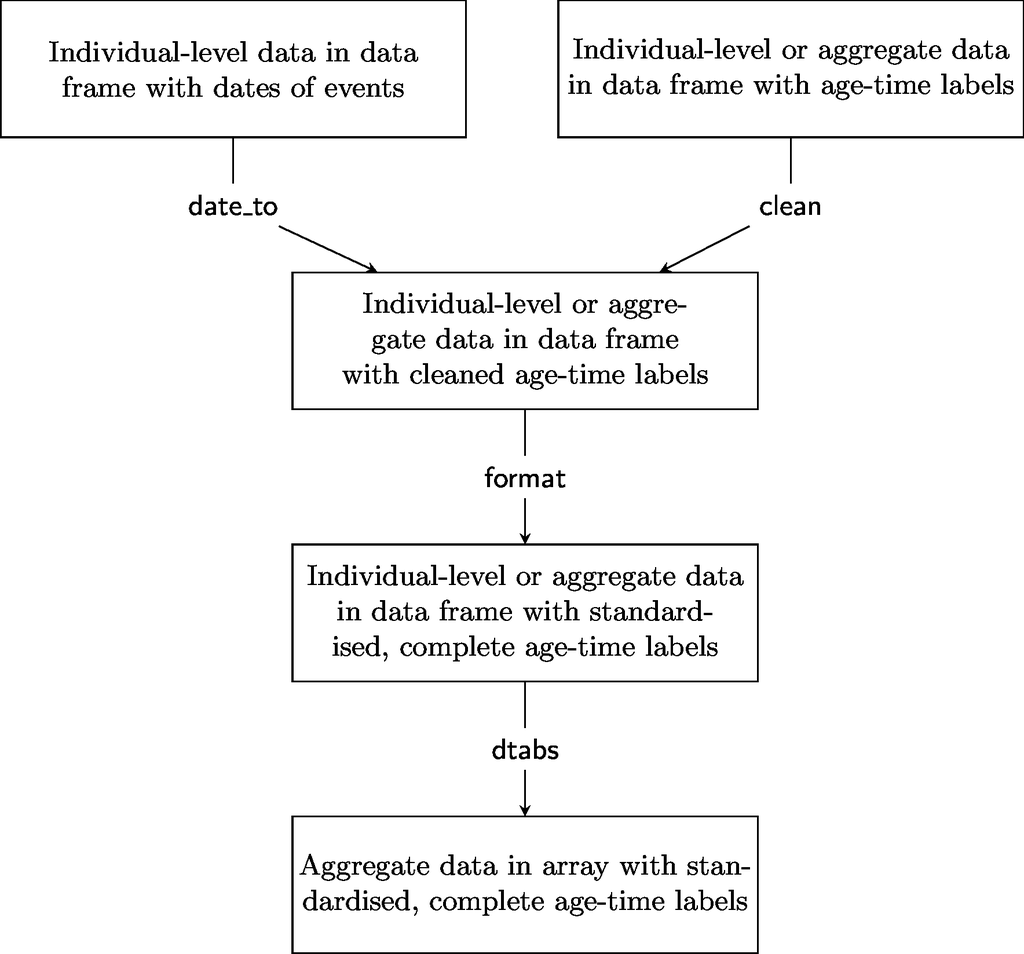

There are, however, a few common data preparation tasks that do not fit neatly into the workflow above, that can be done using **demprep** functions:

**Imputing dates**

When only partial information on dates is provided, the missing information can be imputed using the `impute_date` and `impute_dob`.

**Rotating age, period, cohort, and triangle labels**

**Creating labels based on explicit dates**

**Changing the labeling of one-year periods and cohorts**

## 3.2 The `date_to` functions

### 3.2.1 Overview

Suppose that we have some raw, individual-level data on dates of birth and dates of enrolment in a health care scheme,

```
#>   date_of_birth date_of_enrolment
#> 1    2000-03-07        2002-08-12
#> 2    2010-12-25        2014-01-31
#> 3    2007-02-28        2015-07-01
```

We want to calculate people’s age at the time they enrolled, and the quarter in which they enrolled. We can do calculations, and others like them, using the `date_to` functions.

| Age groups | Periods | Cohorts | Lexis triangles |
| --- | --- | --- | --- |
| `date_to_age_year` | `date_to_period_year` | `date_to_cohort_year` | `date_to_triangle_year` |
| `date_to_age_quarter` | `date_to_period_quarter` | `date_to_cohort_quarter` | `date_to_triangle_quarter` |
| `date_to_age_month` | `date_to_period_month` | `date_to_cohort_month` | `date_to_triangle_month` |

The `year`, `quarter`, and `month` suffixes in the function names describe the measurement units, so that, for example, `date_to_age_month` return’s people’s ages in months, and `date_to_cohort_year` returns people’s year of birth.

To demonstrate the use of the `date_to` functions, we will be using the data frame `deaths`:

```r
deaths <- data.frame(name = c("Anwar", "Baptiste", "Candice"),
                     date_birth = c("2014-02-17", "2012-01-10", "2019-04-29"),
                     date_death = c("2019-10-11", "2020-02-27", "2020-08-01"))
deaths
```

```
#>       name date_birth date_death
#> 1    Anwar 2014-02-17 2019-10-11
#> 2 Baptiste 2012-01-10 2020-02-27
#> 3  Candice 2019-04-29 2020-08-01
```

Before running, we need to load packages **demprep** and (for the pipe `%>%` and various data manipulation functions) **dplyr**.

```r
library(demprep)
library(dplyr)
```

### 3.2.2 Age

The `date_to_age` functions calculate ages denominated in years, quarters, and months.

```r
deaths %>%
  mutate(age_years = date_to_age_year(date = date_death,
                                      dob = date_birth),
         age_quarters = date_to_age_quarter(date = date_death,
                                            dob = date_birth),
         age_months = date_to_age_month(date = date_death,
                                        dob = date_birth))
```

```
#>       name date_birth date_death age_years age_quarters age_months
#> 1    Anwar 2014-02-17 2019-10-11         5           22         67
#> 2 Baptiste 2012-01-10 2020-02-27         8           32         97
#> 3  Candice 2019-04-29 2020-08-01         1            5         15
```

Age is calculated using the approach discussed in Section 2.1, which looks at months and days-within-months attained, rather than absolute number of days. Thus, for example, a person born on 31 January 2001 turns one month old 29 days later, while a person born on 1 February 2001 turns on month old 28 days later.

### 3.2.3 Periods

By default, `date_to_period_year` creates periods that start on 1 January,

```r
deaths %>%
  select(-date_birth) %>%
  mutate(year_start_jan = date_to_period_year(date = date_death))
```

```
#>       name date_death year_start_jan
#> 1    Anwar 2019-10-11           2019
#> 2 Baptiste 2020-02-27           2020
#> 3  Candice 2020-08-01           2020
```

which we might depict as

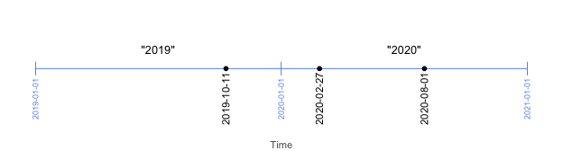

However, other start date are possible, provided that date is the first of the month,

```r
deaths %>%
  select(-date_birth) %>%
  mutate(year_start_apr = date_to_period_year(date = date_death,
                                                month_start = "Apr"))
```

```
#>       name date_death year_start_apr
#> 1    Anwar 2019-10-11           2019
#> 2 Baptiste 2020-02-27           2019
#> 3  Candice 2020-08-01           2020
```

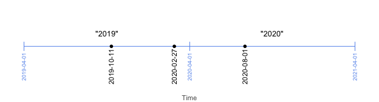

As discussed in Section 2.3, some people base the labels of single-year periods on the calendar year at the start of the period, and others base them on the calendar year at the end. By default, `date_to_period_year` uses the calendar year on the first day of the period. Setting `label_year_start` to `FALSE` makes it use the calendar year on the last day.

```r
deaths %>%
  select(-date_birth) %>%
  mutate(year_label_start = date_to_period_year(date = date_death,
                                                month_start = "Apr"),
         year_label_end = date_to_period_year(date = date_death,
                                              month_start = "Apr",
                                              label_year_start = FALSE))
```

```
#>       name date_death year_label_start year_label_end
#> 1    Anwar 2019-10-11             2019           2020
#> 2 Baptiste 2020-02-27             2019           2020
#> 3  Candice 2020-08-01             2020           2021
```

Labeling quarters and months is simpler. Function `date_to_period_quarter` implements a single set of start dates (1 January, 1 April, 1 July, and 1 October), and a single labeling style.

```r
deaths %>%
  select(-date_birth) %>%
  mutate(quarter = date_to_period_quarter(date_death))
```

```
#>       name date_death quarter
#> 1    Anwar 2019-10-11 2019 Q4
#> 2 Baptiste 2020-02-27 2020 Q1
#> 3  Candice 2020-08-01 2020 Q3
```

`date_to_period_month` is similarly simple/inflexible.

```r
deaths %>%
  select(-date_birth) %>%
  mutate(month = date_to_period_month(date_death))
```

```
#>       name date_death    month
#> 1    Anwar 2019-10-11 2019 Oct
#> 2 Baptiste 2020-02-27 2020 Feb
#> 3  Candice 2020-08-01 2020 Aug
```

### 3.2.4 Cohorts

The `date_to_cohort` functions behave exactly like their `date_to_period` equivalents. To obtain birth cohorts, for instance, we set `date` equal to date of birth.

```r
deaths %>%
  select(-date_death) %>%
  mutate(cohort = date_to_cohort_year(date = date_birth,
                                      month_start = "Apr",
                                      label_year_start = FALSE))
```

```
#>       name date_birth cohort
#> 1    Anwar 2014-02-17   2014
#> 2 Baptiste 2012-01-10   2012
#> 3  Candice 2019-04-29   2020
```

[figure not shown]

### 3.2.5 Lexis triangles

To calculate Lexis triangles, we need dates of events and dates of birth,

```r
deaths %>%
  mutate(triangle = date_to_triangle_year(date = date_death,
                                            dob = date_birth))
```

```
#>       name date_birth date_death triangle
#> 1    Anwar 2014-02-17 2019-10-11    Lower
#> 2 Baptiste 2012-01-10 2020-02-27    Lower
#> 3  Candice 2019-04-29 2020-08-01    Lower
```

[figure not shown]

Like functions `date_to_period_year` and `date_to_cohort_year`, function `date_to_triangle_year` has a `month_start` argument, which shifts the start date of the triangles.

```r
deaths %>%
  mutate(triangle = date_to_triangle_year(date = date_death,
                                            dob = date_birth,
                                                month_start = "Jul"))
```

```
#>       name date_birth date_death triangle
#> 1    Anwar 2014-02-17 2019-10-11    Upper
#> 2 Baptiste 2012-01-10 2020-02-27    Lower
#> 3  Candice 2019-04-29 2020-08-01    Upper
```

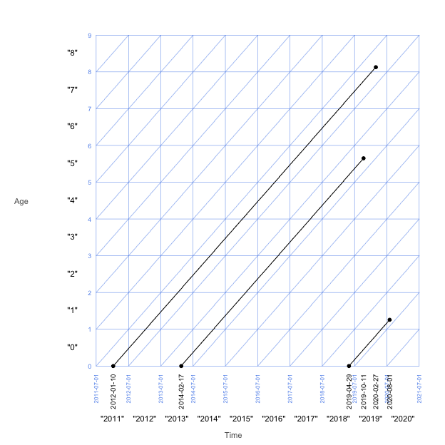

## 3.3 The `clean` functions

Most published demographic data provides age groups and periods, rather than precise dates. Preparing published demographic data for use typically requires cleaning up existing age group and period labels, rather than calculating new ones from scratch. **demprep** provides the following functions for cleaning up existing labels:

| Age groups | Periods | Cohorts |
| --- | --- | --- |
| `clean_age` | `clean_period` | `clean_cohort` |
| `clean_age_df` | `clean_period_df` | `clean_cohort_df` |
| `is_valid_age` | `is_vald_period` | `is_valid_cohort` |

Functions `clean_age`, `clean_period`, and `clean_cohort` try to parse vectors of labels and, where the labels do not conform to **demprep** formats, convert them to these formats. If `clean_age`, `clean_period`, and `clean_cohort` encounter a label they cannot parse, they leave the label untouched.

```r
x <- c("20 years", "80 and over", "young", "20-24")
clean_age(x)
```

```
#> [1] "20"    "80+"   "young" "20-24"
```

Function `clean_age` treats labels consisting entirely of multiples of 5 specially,

```r
x <- seq(0, 60, 5)
x
```

```
#>  [1]  0  5 10 15 20 25 30 35 40 45 50 55 60
```

```r
clean_age(x)
```

```
#>  [1] "0-4"   "5-9"   "10-14" "15-19" "20-24" "25-29" "30-34" "35-39" "40-44"
#> [10] "45-49" "50-54" "55-59" "60+"
```

And also labels that look like they come from a life table,

```r
x <- c(0, 1, seq(5, 80, 5))
x
```

```
#>  [1]  0  1  5 10 15 20 25 30 35 40 45 50 55 60 65 70 75 80
```

```r
clean_age(x)
```

```
#>  [1] "0"     "1-4"   "5-9"   "10-14" "15-19" "20-24" "25-29" "30-34" "35-39"
#> [10] "40-44" "45-49" "50-54" "55-59" "60-64" "65-69" "70-74" "75-79" "80+"
```

Functions `clean_cohort` and `clean_period` are identical to each other, except that `clean_cohort` accepts intervals that are open on the left, while `clean_period` does not.

```r
x <- c("Q1 2020", "1922", "2010-2025", "before 2020")
clean_cohort(x)
```

```
#> [1] "2020 Q1"   "1922"      "2010-2025" "<2020"
```

```r
clean_period(x)
```

```
#> [1] "2020 Q1"     "1922"        "2010-2025"   "before 2020"
```

To see how `clean_age`, `clean_period`, and `clean_cohort` have interpreted some labels, use functions`clean_age_df`, `clean_period_df`, and `clean_cohort_df`.

```r
x <- c("2021", "2022-2025", "2021", "q2 2020")
clean_period_df(x)
```

```
#>       input    output is_valid
#> 1      2021      2021     TRUE
#> 2 2022-2025 2022-2025     TRUE
#> 3   q2 2020   2020 Q2     TRUE
```

To check whether `clean_age`, `clean_period`, and `clean_cohort` have been able to parse the entire vector, use functions `is_valid_age`, `is_valid_period`, and `is_valid_cohort` do.

```r
x <- c("2021", "the 1960s", "1960-1970")
is_valid_period(x)
```

```
#> [1]  TRUE FALSE  TRUE
```

To catch problematic inputs, some version of

```r
stopifnot(all(is_valid_period(x)))
```

is often useful.

## 3.4 The `format` functions

### 3.4.1 Overview

Demographic analyses usually require data to be arranged into age groups, periods, or cohorts, of standardised lengths, with all intermediate categories included. Tabulations should look like this

| Age | 2020-2025 | 2025-2030 |
| --- | --- | --- |
| 0-4 | 1 | 3 |
| 5-9 | 4 | 8 |
| 10-14 | 0 | 3 |

rather than this

| Age | 2020 | 2022-2023 | 2025-2030 |
| --- | --- | --- | --- |
| 0-2 | 1 | 0 | 2 |
| 4 | 0 | 0 | 1 |
| 5-8 | 1 | 3 | 8 |
| 10-12 | 0 | 0 | 2 |
| 14 | 0 | 0 | 1 |

The `format` functions take vectors of age, period, cohort, and Lexis triangle labels that conform to **dem** package conventions, and return factors where the intervals have standardised lengths, and where all intermediate categories, including ones that do not appear in the data, are included.

| Age groups | Periods | Cohorts | Lexis triangles |
| --- | --- | --- | --- |
| `format_age_year` | `format_period_year` | `format_cohort_year` | `format_triangle_year` |
| `format_age_multi` | `format_period_multi` | `format_cohort_multi` | `format_triangle_multi` |
| `format_age_custom` | `format_period_custom` | `format_cohort_custom` | <none> |
| `format_age_lifetab` | <none> | <none> | <none> |
| `format_age_births` | <none> | <none> | `format_triangle_births` |
| `format_age_quarter` | `format_period_quarter` | `format_cohort_quarter` | `format_triangle_quarter` |
| `format_age_month` | `format_period_month` | `format_cohort_month` | `format_triangle_month` |

The last part of the function names describe the units that are returned. Functions `format_age_year`, `format_age_quarter`, and `format_age_month`, for instance, create labels where the intervals have lengths of one year, one quarter, and one month. Functions ending in `multi` return labels where then intervals can span multiple years, provided that the intervals all have the same length. Function `format_period_multi` can be used, for instance, to create labels for periods with widths of 5 years. `Functions ending in`custom`also return labels where the intervals can span multiple years, but the intervals do not all have to be the same length. Function`format_age_lifetab`deals with age groups used in life tables, and function`format_age_births` deals with age groups used for describing births.

When, for example, `format_age_multi` is supplied with a vector that uses single years of age, by default it converts these into 5-year age group labels:

```r
original <- c(11, 93, 15, 30)
reformatted <- format_age_multi(original)
reformatted
```

```
#> [1] 10-14 90-94 15-19 30-34
#> 21 Levels: 0-4 5-9 10-14 15-19 20-24 25-29 30-34 35-39 40-44 45-49 ... 100+
```

The object holding the new 5-year labels is a factor.

```r
class(reformatted)
```

```
#> [1] "factor"
```

A factor contain a “levels” attribute that lists all possible labels.

```r
levels(reformatted)
```

```
#>  [1] "0-4"   "5-9"   "10-14" "15-19" "20-24" "25-29" "30-34" "35-39" "40-44"
#> [10] "45-49" "50-54" "55-59" "60-64" "65-69" "70-74" "75-79" "80-84" "85-89"
#> [19] "90-94" "95-99" "100+"
```

Tabulation functions such as `table`, `xtabs`, or `dtabs` (described below) make use of the levels.

```r
table(reformatted)
```

```
#> reformatted
#>   0-4   5-9 10-14 15-19 20-24 25-29 30-34 35-39 40-44 45-49 50-54 55-59 60-64
#>     0     0     1     1     0     0     1     0     0     0     0     0     0
#> 65-69 70-74 75-79 80-84 85-89 90-94 95-99  100+
#>     0     0     0     0     0     1     0     0
```

The tabulations include counts for all levels, including ones that do not appear in the data, which receive counts of zero. Including all levels is normally what we want when we are tabulating data for demographic analyses.

If we convert the factor into a character vector, the special behaviour is lost.

```r
table(as.character(reformatted))
```

```
#>
#> 10-14 15-19 30-34 90-94
#>     1     1     1     1
```

Most of the `format` functions provide some control over the range of the labels. With `format_age_multi`, for instance, we can specify that the first age group starts at 10 rather than 0,

```r
format_age_multi(original, break_min = 10)
```

```
#> [1] 10-14 90-94 15-19 30-34
#> 19 Levels: 10-14 15-19 20-24 25-29 30-34 35-39 40-44 45-49 50-54 ... 100+
```

The `format` functions work on labels as well as numbers,

```r
x <- c("2020-2021", "2018", "2020-2025", "<2015")
format_cohort_multi(x)
```

```
#> setting 'open_first' to TRUE
#> setting 'break_min' to 2015
#> [1] 2020-2025 2015-2020 2020-2025 <2015
#> Levels: <2015 2015-2020 2020-2025
```

### 3.4.2 Age groups

Arguments `break_min`, `break_max`, and `open_last` can be used to control lower and upper limits of the age group labels. The default behavior for `format_age_year` and `format_age_multi`, for instance, is to create ordinary age groups between ages 0 and 100, and an open age group after that,

```r
x <- c("35-38", "50-54", "77")
format_age_multi(x, width = 10)
```

```
#> [1] 30-39 50-59 70-79
#> Levels: 0-9 10-19 20-29 30-39 40-49 50-59 60-69 70-79 80-89 90-99 100+
```

Alternative lower and upper limits can be specified via the `break_min` and `break_max` arguments,

```r
x <- c("35-38", "50-54", "77")
format_age_multi(x,
                 width = 10,
                 break_min = 20,
                 break_max = 90)
```

```
#> [1] 30-39 50-59 70-79
#> Levels: 20-29 30-39 40-49 50-59 60-69 70-79 80-89 90+
```

The open interval can be removed using the ‘open_last’ argument,

```r
x <- c("35-38", "50-54", "77")
format_age_multi(x,
                 width = 10,
                 break_min = 20,
                 break_max = 90,
                 open_last = FALSE)
```

```
#> [1] 30-39 50-59 70-79
#> Levels: 20-29 30-39 40-49 50-59 60-69 70-79 80-89
```

Setting `break_min` and `break_max` to `NULL` allows the limits to be set by the data.

```r
x <- c("35-38", "50-54", "77")
format_age_multi(x,
                 width = 10,
         break_min = NULL,
         break_max = NULL)
```

```
#> setting 'break_min' to 35
#> setting 'break_max' to 85
#> [1] 35-44 45-54 75-84
#> Levels: 35-44 45-54 55-64 65-74 75-84 85+
```

When age groups with variable lengths are needed, function `format_age_custom` can be used. The age groups are defined via the `breaks` argument

```r
x <- c("35-38", "50-54", "77")
format_age_custom(x, breaks = c(15, 40, 80))
```

```
#> [1] 15-39 40-79 40-79
#> Levels: 15-39 40-79 80+
```

Function `format_age_lifetab` creates the special age groups needed for an “abridged” life table (ie a life table with age groups `"0"`, `"1-4"`, `"5-9"`, `"10-14"`, `"15-19"`, etc.

```r
x <- c("35-38", "50-54", "77")
format_age_lifetab(x)
```

```
#> [1] 35-39 50-54 75-79
#> 22 Levels: 0 1-4 5-9 10-14 15-19 20-24 25-29 30-34 35-39 40-44 45-49 ... 100+
```

The other specialsed `format_age` function is `format_age_biths`, which creates age groups for birth rates or counts,

```r
x <- c("22", "30-33", "18", "40-44")
format_age_births(x)
```

```
#> [1] 20-24 30-34 15-19 40-44
#> Levels: 15-19 20-24 25-29 30-34 35-39 40-44 45-49
```

Function `format_age_biths` can recode values that fall outside the expected range,

```r
x <- c("10", "30-33")
format_age_births(x, recode_up = TRUE)
```

```
#> [1] 15-19 30-34
#> Levels: 15-19 20-24 25-29 30-34 35-39 40-44 45-49
```

### 3.4.3 Periods

The `format_period` functions, in contrast to the `format_age` functions do not have `break_min` and `break_max` arguments. Instead, the range of the labels is set by the data (like what happens with the `format_age` functions when `break_min` and `break_max` are set to `NULL`.)

The ambiguities of single-year period labels mean that functions `format_period_multi` and `format_period_custom` need extra information to parse these labels and align them to other labels. By default, `format_period_multi` and `format_period_custom` treats single-year periods as beginning in January. Under the default settings, the label `"2050"` refers to the period between 1 January 2050 and 31 December 2050, the label `"2050-2055"` refers the period between 1 January 2050 and 31 December 2054, and the first period falls within the second.

```r
x <- c("2050", "2050-2055")
format_period_multi(x)
```

```
#> [1] 2050-2055 2050-2055
#> Levels: 2050-2055
```

However, if we set `month_start` to `"July"' and`label_year_start`to`FALSE`, then`“2050”`refers to the period between 1 July 2049 and 30 June 2050,`“2050-2055”` refers to the period between 1 July 2050 and 31 June 2055, and the first period falls outside the second.

```r
x <- c("2050", "2050-2055")
format_period_multi(x,
                    month_start = "July",
            label_year_start = FALSE)
```

```
#> [1] 2045-2050 2050-2055
#> Levels: 2045-2050 2050-2055
```

Multi-year periods that start on, say, 2021 rather than 2020, can be obtained by changing the `origin` argument from its default value of 2000. The absolute value of `origin` does not in fact matter - only the remainder when it is divided by `width`.

```r
x <- c("2020", "2021", "2027-2028")
format_period_multi(x)
```

```
#> [1] 2020-2025 2020-2025 2025-2030
#> Levels: 2020-2025 2025-2030
```

```r
format_period_multi(x, origin = 2021)
```

```
#> [1] 2016-2021 2021-2026 2026-2031
#> Levels: 2016-2021 2021-2026 2026-2031
```

### 3.4.4 Cohorts

The `format_cohort` functions work exactly like the equivalent `format_period` functions, except that the `format_cohort` functions allow for the possibility of an interval that is open on the left.

```r
x <- c("2003", "1998", "2015", "1984", "2002")
format_cohort_year(x)
```

```
#> setting 'open_first' to FALSE
#> setting 'break_min' to 1984
#> [1] 2003 1998 2015 1984 2002
#> 32 Levels: 1984 1985 1986 1987 1988 1989 1990 1991 1992 1993 1994 1995 ... 2015
```

```r
format_cohort_year(x, break_min = 1990)
```

```
#> setting 'open_first' to TRUE
#> [1] 2003  1998  2015  <1990 2002
#> 27 Levels: <1990 1990 1991 1992 1993 1994 1995 1996 1997 1998 1999 ... 2015
```

A birth cohort with no lower limit is equivalent to an age group with no upper limit. On 31 December 2019, for instance, the cohort `“<1920” is equivalent to the age group 100+.

### 3.4.5 Lexis triangles

The `format_triangle` functions produce Lexis triangles that have consistent lengths. To aggregate triangles, the `format_triangle` functions need information on age, and, in the case of `format_triangle_multi` and `format_triangle_births`, detailed information on periods.

```r
x <- c("Lower", "Upper", "Lower")
age <- c("22", "56", "103")
format_triangle_year(x = x, age = age)
```

```
#> [1] Lower Upper Upper
#> Levels: Lower Upper
```

## 3.5 The `dtabs` functions

### 3.5.1 The `dtabs` function for ordinary tabulation

xtabs for tabulation, but nice formula-based way of turning general data frame into array.

Once all the variables have been put into the required formats, we can tabulate the data. The most powerful tabulation function in base R is `xtabs`. **demprep** contains a modified version of `xtabs` called `dtabs`. `dtabs` is designed to be simpler and safer than `xtabs`, particularly for constructing demographic arrays. The differences between `xtabs` and `dtabs` are

[output not shown]

Using a pipe (`%>%` or `|>`) is slightly easier when the `data` argument comes first than when it comes second. In `xtabs` the `data` argument comes second,

```r
df <- data.frame(y = c(1, 2, 1),
                 x = c("a", "b", "b"))
df %>%
  xtabs(y ~ x, .) # need '.' as placeholder for data
```

```
#> x
#> a b
#> 1 3
```

In `dtabs`, the `data` argument comes first,

```r
df %>%
  dtabs(y ~ x)
```

```
#> setting 'fill' to 0
#> x
#> a b
#> 1 3
```

When an `NA` appears in a cross-classifying variable, `xtabs` by default silently suppresses it,

```r
df <- data.frame(y = c(1, 2, 1),
                 x = c("a", "b", NA))
df %>%
  xtabs(y ~ x, .)
```

```
#> x
#> a b
#> 1 2
```

`dtabs`, in contrast, treats the `NA` as an extra level,

```r
df <- data.frame(y = c(1, 2, 1),
                 x = c("a", "b", NA))
df %>%
  dtabs(y ~ x)
```

```
#> setting 'fill' to 0
#> x
#>    a    b <NA>
#>    1    2    1
```

Similarly, when an `NA` appears in the response variable, `xtabs` silently suppresses it

```r
df <- data.frame(y = c(1, 2, NA),
                 x = c("a", "b", "a"))
df %>%
  xtabs(y ~ x, .)
```

```
#> x
#> a b
#> 1 2
```

`dtabs`, in contrast, defaults to keeping the `NA`,

```r
df <- data.frame(y = c(1, 2, NA),
                 x = c("a", "b", "a"))
df %>%
  dtabs(y ~ x)
```

```
#> setting 'fill' to 0
#> x
#>  a  b
#> NA  2
```

(though the `NA` can be dropped by setting `na_rm` to `TRUE`.)

The reason for forcing users to explicitly deal with `NA`s is that treatment of `NA`s is an important methodological that deserves the user’s attention. “Complete case analyses”, where `NA`s are simply dropped from the data, can be seriously misleading (see, for instance, Little’s and Rubin’s book *Statistical analysis with missing data*.)

Another important difference between `xtabs` and `dtabs` is the way that the two functions handle combinations of cross-classifying variables that do not appear in the data. `xtabs` always gives missing combinations a value of 0. For instance, when a dataset has no one who is aged 5-9 years and also male, then it assigns a 0 to this combination,

```r
df <- data.frame(y = c(1, 2, 3),
                 age = c("0-4", "5-9", "0-4"),
                 sex = c("Female", "Female", "Male"))
df %>%
  xtabs(y ~ age + sex, .)
```

```
#>      sex
#> age   Female Male
#>   0-4      1    3
#>   5-9      2    0
```

This is the correct behaviour when using `xtabs` for iss original purpose, which to tabulate counts. But it is not when we want if we are using `xtabs` to convert a data frame of non-count values into an array. In the following example, `0` is *not* a sensible value for the missing combination.

```r
df <- data.frame(y = c(33.3, -4.1, 22.9),
                 age = c("0-4", "5-9", "0-4"),
                 sex = c("Female", "Female", "Male"))
df %>%
  xtabs(y ~ age + sex, .)
```

```
#>      sex
#> age   Female Male
#>   0-4   33.3 22.9
#>   5-9   -4.1  0.0
```

`dtabs` allows users specify the value that is used for combinations of variables that do not appear in the data. The value is specified via the `fill` argument,

```r
df <- data.frame(y = c(33.3, -4.1, 22.9),
                 age = c("0-4", "5-9", "0-4"),
                 sex = c("Female", "Female", "Male"))
df %>%
  dtabs(y ~ age + sex, fill = NA)
```

```
#>      sex
#> age   Female Male
#>   0-4   33.3 22.9
#>   5-9   -4.1   NA
```

A final difference between `xtabs` and `dtabs` is that `xtabs` allows the user to take subsets of the data, or drop unused levels from factors, as part of the tabulation while `dtabs` does not. Limiting the options in `dtabs` makes the function easier to understand. It also forces the users to write seperate calls to funtions such as `subset` or `droplevels`, which makes the code easier to understand.

### 3.5.2 The `dtabs_survey` function for the tabulation of survey data on binary outcomes

**demprep** has a specialised version of `dtabs`, called `dtabs_survey` for tabulating survey data on binary (yes-no) outcomes. `dtabs_survey` calculates “effective” numbers of trials and successes that allow data from a complex survey to be analysed as if it came from a simple random survey. Doing so sacrifices some accuracy in return for a large increase in convenience.

## 3.6 Other functions

### 3.6.1 Imputing dates

Sometimes input data has incomplete data on dates, such as having the year and month of births but not the days. One way of dealing with incomplete data is to impute the missing information. This is what functions `impute_date` and `impute_dob` are for.

The imputation is random, so, for repeatability, we set the random seed.

```r
set.seed(0)
```

In our first example, we know the year and month of some events, but not the day, so we use `impute date`.

```r
impute_date(year = c(2000, 2005, 2003),
            month = c("Feb", "Nov", "Apr"))
```

```
#> [1] "2000-02-27" "2005-11-08" "2003-04-12"
```

In our second example, we know the dates of events, and we know people’s age in years at the time of the eevents, and we want to impute dates of birth.

```r
impute_dob(date = c("2021-03-23", "2021-02-13", "2020-04-25"),
           age_years = c(3, 1, 0))
```

```
#> [1] "2017-10-19" "2020-01-11" "2019-07-08"
```

### 3.6.2 Rotating age, period, cohort, Lexis triangle

### 3.6.3 Labels based on date ranges

The ambiguities of period and cohort labels do not normally cause any problems when working with a single dataset. When working with multiple datasets, however, aligning periods correctly can be confusing and error-prone.

The functions

| `as_date_range_year` |
| --- |
| `as_date_range_multi` |
| `as_date_range_custom` |
| `as_date_range_quarter` |
| `as_date_range_month` |

convert from standared period and cohort labels to nonstandard but unambiguous ones that use explicit dates.

By default, `month_start` is set to `"Jan"` and `label_year_start` is set to `TRUE`

```r
x <- c("2022", "2028")
as_date_range_year(x)
```

```
#> [1] [2022-01-01, 2022-12-31] [2028-01-01, 2028-12-31]
#> Levels: [2022-01-01, 2022-12-31] [2028-01-01, 2028-12-31]
```

Different settings give different interpretations of the same labels,

```r
x <- c("2022", "2028")
as_date_range_year(x,
                   month_start = "Mar",
                   label_year_start = FALSE)
```

```
#> [1] [2021-03-01, 2022-02-28] [2027-03-01, 2028-02-29]
#> Levels: [2021-03-01, 2022-02-28] [2027-03-01, 2028-02-29]
```

### 3.6.4 Flipping year labels

# 4 Examples

```r
set.seed(0)
```

## 4.1 Counts of deaths in New Zealand

```r
deaths <- demprep::nzdeaths
deaths %>%
  sample_n(5)
```

```
#>           age    sex year count
#> 1 45-49 years   Male 2020   375
#> 2 95-99 years Female 2019  1245
#> 3 25-29 years   Male 2019   144
#> 4   1-4 years   Male 2020    24
#> 5 30-34 years Female 2019    87
```

```r
unique(deaths$age)
```

```
#>  [1] "Total all ages"     "Infant"             "1-4 years"
#>  [4] "5-9 years"          "10-14 years"        "15-19 years"
#>  [7] "20-24 years"        "25-29 years"        "30-34 years"
#> [10] "35-39 years"        "40-44 years"        "45-49 years"
#> [13] "50-54 years"        "55-59 years"        "60-64 years"
#> [16] "65-69 years"        "70-74 years"        "75-79 years"
#> [19] "80-84 years"        "85-89 years"        "90-94 years"
#> [22] "95-99 years"        "100 years and over"
```

```r
deaths <- deaths %>%
  filter(age != "Total all ages") %>%
  mutate(age = clean_age(age))
unique(deaths$age)
```

```
#>  [1] "0"     "1-4"   "5-9"   "10-14" "15-19" "20-24" "25-29" "30-34" "35-39"
#> [10] "40-44" "45-49" "50-54" "55-59" "60-64" "65-69" "70-74" "75-79" "80-84"
#> [19] "85-89" "90-94" "95-99" "100+"
```

```r
deaths <- deaths %>%
  mutate(age = format_age_multi(age, width = 10))
unique(deaths$age)
```

```
#>  [1] 0-9   10-19 20-29 30-39 40-49 50-59 60-69 70-79 80-89 90-99 100+
#> Levels: 0-9 10-19 20-29 30-39 40-49 50-59 60-69 70-79 80-89 90-99 100+
```

```r
deaths <- deaths %>%
  mutate(year = flip_year_label(year))
unique(deaths$year)
```

```
#> [1] 2019 2020
#> Levels: 2019 2020
```

```r
deaths <- deaths %>%
  dtabs(count ~ age + sex + year)
```

```
#> setting 'fill' to 0
```

```r
deaths
```

```
#> , , year = 2019
#>
#>        sex
#> age     Female Male Total Both Sexes
#>   0-9      168  162              330
#>   10-19     81  135              210
#>   20-29    126  303              429
#>   30-39    183  321              504
#>   40-49    399  552              951
#>   50-59    975 1422             2397
#>   60-69   1797 2409             4212
#>   70-79   3117 4143             7260
#>   80-89   5313 5301            10611
#>   90-99   4053 2307             6354
#>   100+     255   51              309
#>
#> , , year = 2020
#>
#>        sex
#> age     Female Male Total Both Sexes
#>   0-9      123  204              324
#>   10-19     66   96              162
#>   20-29    120  264              384
#>   30-39    174  339              510
#>   40-49    402  597             1002
#>   50-59    996 1329             2322
#>   60-69   1695 2541             4242
#>   70-79   3102 4311             7419
#>   80-89   5337 5334            10674
#>   90-99   4068 2364             6429
#>   100+     291   51              345
```

## 4.2 Counts of births in Iceland

Births in the calendary years 1981 to 2019. Want array of birth by period of birth, age of father, Lexis triangle of father. Five-year age groups and periods. Start in 1981.

```r
births <- demprep::icebirths
births %>%
  sample_n(5)
```

```
#>    dob_child dob_father
#> 1 1987-02-06 1955-03-29
#> 2 1988-10-21 1962-02-12
#> 3 2011-02-16 1980-03-13
#> 4 2008-03-24 1980-03-26
#> 5 1984-03-26 1960-06-29
```

```r
births <- births %>%
  mutate(period1 = date_to_period_year(dob_child))
births %>%
  sample_n(5)
```

```
#>    dob_child dob_father period1
#> 1 1982-11-29 1958-11-04    1982
#> 2 1987-02-18 1962-12-05    1987
#> 3 2002-02-17 1964-01-29    2002
#> 4 1986-05-17 1959-11-24    1986
#> 5 2005-08-02 1977-07-08    2005
```

```r
births <- births %>%
  mutate(age1 = date_to_age_year(date = dob_child,
                                 dob = dob_father))
births %>%
  sample_n(5)
```

```
#>    dob_child dob_father period1 age1
#> 1 1983-11-01 1956-12-23    1983   26
#> 2 2002-08-14 1972-07-19    2002   30
#> 3 2006-04-25 1982-09-10    2006   23
#> 4 2019-11-19 1988-10-12    2019   31
#> 5 2003-09-03 1969-12-09    2003   33
```

```r
births <- births %>%
  mutate(triangle1 = date_to_triangle_year(date = dob_child,
                                           dob = dob_father))
births %>%
  sample_n(5)
```

```
#>    dob_child dob_father period1 age1 triangle1
#> 1 1991-07-29 1962-01-23    1991   29     Lower
#> 2 2009-05-16 1977-06-03    2009   31     Upper
#> 3 1982-07-09 1955-06-13    1982   27     Lower
#> 4 2002-07-15 1975-06-22    2002   27     Lower
#> 5 2015-09-18 1976-06-10    2015   39     Lower
```

```r
births <- births %>%
  mutate(period = format_period_multi(period1,
                                      origin = 1981))
births %>%
  sample_n(5)
```

```
#>    dob_child dob_father period1 age1 triangle1    period
#> 1 2001-05-01 1953-01-14    2001   48     Lower 2001-2006
#> 2 2008-01-27 1973-07-11    2008   34     Upper 2006-2011
#> 3 2009-07-23 1964-11-23    2009   44     Upper 2006-2011
#> 4 2009-01-28 1973-06-17    2009   35     Upper 2006-2011
#> 5 1986-04-08 1970-10-22    1986   15     Upper 1986-1991
```

```r
births <- births %>%
  mutate(age = format_age_births(x = age1,
                                 width = 5,
                                 break_min = 15,
                                 break_max = NULL,
                                 recode_up = TRUE))
```

```
#> setting 'break_max' to 70
```

```r
births %>%
  sample_n(5)
```

```
#>    dob_child dob_father period1 age1 triangle1    period   age
#> 1 2002-04-02 1965-01-06    2002   37     Lower 2001-2006 35-39
#> 2 2007-04-20 1979-05-27    2007   27     Upper 2006-2011 25-29
#> 3 2016-03-29 1985-05-13    2016   30     Upper 2016-2021 30-34
#> 4 1984-01-30 1953-10-28    1984   30     Upper 1981-1986 30-34
#> 5 1982-11-07 1949-07-06    1982   33     Lower 1981-1986 30-34
```

```r
births <- births %>%
  mutate(triangle = format_triangle_multi(triangle1,
                                          age = age1,
                                          period = period1,
                                          origin = 1981))
births %>%
  sample_n(10)
```

```
#>     dob_child dob_father period1 age1 triangle1    period   age triangle
#> 1  1983-03-02 1959-02-11    1983   24     Lower 1981-1986 20-24    Upper
#> 2  1981-11-23 1959-06-13    1981   22     Lower 1981-1986 20-24    Upper
#> 3  2009-07-27 1982-07-26    2009   27     Lower 2006-2011 25-29    Lower
#> 4  1987-07-09 1954-09-04    1987   32     Upper 1986-1991 30-34    Upper
#> 5  2005-09-02 1977-05-09    2005   28     Lower 2001-2006 25-29    Lower
#> 6  1984-04-02 1960-06-21    1984   23     Upper 1981-1986 20-24    Upper
#> 7  2018-09-27 1990-11-09    2018   27     Upper 2016-2021 25-29    Upper
#> 8  1990-04-01 1948-07-24    1990   41     Upper 1986-1991 40-44    Lower
#> 9  2017-12-30 1996-06-07    2017   21     Lower 2016-2021 20-24    Lower
#> 10 1996-04-19 1960-02-05    1996   36     Lower 1996-2001 35-39    Upper
```

```r
births %>%
  filter(triangle != triangle1) %>%
  sample_n(5)
```

```
#>    dob_child dob_father period1 age1 triangle1    period   age triangle
#> 1 1987-12-05 1953-03-06    1987   34     Lower 1986-1991 30-34    Upper
#> 2 1989-01-21 1961-08-13    1989   27     Upper 1986-1991 25-29    Lower
#> 3 1983-12-01 1955-03-09    1983   28     Lower 1981-1986 25-29    Upper
#> 4 1990-08-22 1961-09-07    1990   28     Upper 1986-1991 25-29    Lower
#> 5 1998-01-20 1961-12-07    1998   36     Upper 1996-2001 35-39    Lower
```

```r
births_array <- births %>%
  filter(period != "2016-2021") %>%
  dtabs(~ age + triangle + period)
```

```
#> setting 'fill' to 0
```

```r
dimnames(births_array)
```

```
#> $age
#>  [1] "15-19" "20-24" "25-29" "30-34" "35-39" "40-44" "45-49" "50-54" "55-59"
#> [10] "60-64" "65-69"
#>
#> $triangle
#> [1] "Lower" "Upper"
#>
#> $period
#> [1] "1981-1986" "1986-1991" "1991-1996" "1996-2001" "2001-2006" "2006-2011"
#> [7] "2011-2016" "2016-2021"
```

```r
births_array
```

```
#> , , period = 1981-1986
#>
#>        triangle
#> age     Lower Upper
#>   15-19   164   674
#>   20-24  2226  3123
#>   25-29  3467  3313
#>   30-34  2551  2150
#>   35-39  1311   910
#>   40-44   399   270
#>   45-49   118    92
#>   50-54    39    33
#>   55-59    11     8
#>   60-64     4     2
#>   65-69     2     0
#>
#> , , period = 1986-1991
#>
#>        triangle
#> age     Lower Upper
#>   15-19   126   425
#>   20-24  1729  2572
#>   25-29  3511  3489
#>   30-34  3306  2518
#>   35-39  1812  1120
#>   40-44   645   320
#>   45-49   145    94
#>   50-54    44    25
#>   55-59    15    10
#>   60-64     3     2
#>   65-69     2     0
#>
#> , , period = 1991-1996
#>
#>        triangle
#> age     Lower Upper
#>   15-19    88   351
#>   20-24  1380  2120
#>   25-29  3160  3513
#>   30-34  3315  2994
```

[output cut: 72 more lines]

```
#> , , period = 2016-2021
#>
#>        triangle
#> age     Lower Upper
#>   15-19     0     0
#>   20-24     0     0
#>   25-29     0     0
#>   30-34     0     0
#>   35-39     0     0
#>   40-44     0     0
#>   45-49     0     0
#>   50-54     0     0
#>   55-59     0     0
#>   60-64     0     0
#>   65-69     0     0
```

## 4.3 An example involving rates